# Notebook for event file creation: for the gradient analysis (SpaNov)

Joern Alexander Quent

Analysis date: 2025-08-21

# General notes

This scripts creates the event files for the gradient analysis for the SpaNov paper.

Here is some background how to combine to measure into one:

- https://stats.stackexchange.com/questions/199085/how-to-create-a-pca-based-index-from-two-variables-when-their-directions-are-opp
- https://stats.stackexchange.com/questions/140434/does-a-correlation-matrix-of-two-variables-always-have-the-same-eigenvectors

```r
noveltyLvl <- c(6)
numLevels  <- length(noveltyLvl)
```

# Libraries used

```r
# Install via devtools:install_github("JAQuent/assortedRFunctions", upgrade = "never")
library(assortedRFunctions)
library(plyr)
library(ggplot2)
library(stringr)
library(cowplot)
library(foreach)
library(doParallel)
library(knitr)
library(data.table)
library(fmri)
library(HH)
library(reshape2)
```

# Data preparation

**Click here for code for data preparation.**

```r
# Path 2 where the data is saved
path2data        <- "data/ignore_fMRI_version1/"
lookupTable      <- read.csv(paste0(path2data, "lookUpTable.csv"))
```

```r
# Current task folder
taskFolder <- paste0(path2data, "OLM_grassy/")

# Load the subjects that are included in this analysis
subjectFile  <- readLines(paste0(path2data, "SpaNov_subject2analyse.txt"))
subjIDs    <- str_split(subjectFile, pattern = ",")[[1]]

# Create list of all files and load them
allFiles   <- paste0(taskFolder, subjIDs, '/S007/trial_results.csv')
trial_results <- do.call(rbind, lapply(allFiles, read.csv, quote = ""))

# Remove rows with NA values
#trial_results <- na.omit(trial_results)
trial_results <- trial_results[!is.na(trial_results$runStartTime),]

# Relabel ppid to subject to be compatible
trial_results$subject <- trial_results$ppid

# Get cue times
cues_agg <- data.frame(ppid = trial_results$ppid,
                       trial = trial_results$trial_num,
                       start = trial_results$start_time,
                       end = trial_results$start_time + trial_results$cue,
                       duration = trial_results$cue,
                       block_num = trial_results$block_num)
# Get delay times
delays_agg <- data.frame(ppid = trial_results$ppid,
                         trial = trial_results$trial_num,
                         start = trial_results$start_time + trial_results$cue,
                         end = trial_results$start_time + trial_results$cue + trial_results$delay,
                         duration = trial_results$delay,
                         block_num = trial_results$block_num)
```

```r
# Current task folder
taskFolder <- paste0(path2data, "OLM_grassy/")

# Loop through all subjects
# Create empty list
tempList <- list()

# Loop through all subject folders
for(i in 1:length(subjIDs)){
  # Not this code will only work correctly if the folder only contains position tracker
  # Get all files
  path2tracker <- paste0(taskFolder, subjIDs[i], '/S007/trackers/')
  allTrackers  <- paste0(path2tracker, list.files(path2tracker))

  # Get list of DFs
  tempTracker <- lapply(allTrackers, read.csv)

  # Add index as subject and then bind together
  tempList[[i]] <- custom_rbinder_addIndexColumn(tempTracker, "trial")
}

# Bind this list to 1 DF with subject index
positionData <- custom_rbinder_addIndexColumn(tempList, "subject")

# Add ppid to the data frame
## Get subject rle
subject_rle <- rle(positionData$subject)

# Add ppid to data frame
positionData$ppid <- rep(subjIDs, times = subject_rle$lengths) # Repeat each R number in subjIDs according to the run length of subject
# This works because the subjects are loaded in the order of subject_rle

# Get how often the variables that will be added to the movement DF has to be repeated
trial_rle <- rle(positionData$trial) # Get run length encoding so we know how often we need to repeat the trial type and other variables

# Add the trial type to the position data
positionData$trialType <- rep(trial_results$trialType, times = trial_rle$lengths) # Repeat trial type and add to position data
```

## Folder & file naming convention

The naming convention for the gradient analysis is: SpaNov_gradient_xlvl with x for the number of novelty/familiarity levels used in this analysis. The level of smoothing is additionally indicated by adding “_smo6” or “_smo2” add the end. Since the files created here are used with at least two different levels of smoothing, this was done by copying and re-naming the resulting folders.

**Code to create file & folder names**

```r
# String parts
task <- "OLM"

# Other information
folder    <- "event_tables/"
session   <- "S007"
runs      <- c(1, 1, 2, 2) # OlMe run1, OLMr run 1, OLMe run 2 etc.
runType   <- c("e", "r", "e", "r")

# Create folders for this subject and for the session
ses <- 1

# Creating the subject folders
OLMe_7T_SpaNovGradient1 <- paste0(folder, paste0("OLMe_7T_SpaNov_gradient_", rep(noveltyLvl, each = length(subjIDs)), "lvl/"), "sub-", rep(subjIDs, length(noveltyLvl)), "/ses-", sprintf("%02d", ses), "/")
OLMr_7T_SpaNovGradient1 <- paste0(folder, paste0("OLMr_7T_SpaNov_gradient_", rep(noveltyLvl, each = length(subjIDs)), "lvl/"), "sub-", rep(subjIDs, length(noveltyLvl)), "/ses-", sprintf("%02d", ses), "/")
```

# Downsample the data

```r
# Parameter
downsample_value  <- 0.2 #200 msec/0.2 sec
```

The position data that we have recorded is approximately 60 Hz. For the present analysis is unnecessarily high (for fMRI) increasing the computational load. We therefore downsample to approximately 5 Hz.

```r
# Add run information
run_info <- ddply(trial_results, c("block_num", "trial_num"), summarise, N = length(ppid))
positionData$run <- NA

# Loop through all trials
for(i in 1:nrow(run_info)){
  positionData$run[positionData$trial == run_info$trial_num[i]] <- run_info$block_num[i]
}

startTime <- Sys.time()

# Prepare the cluster for a parallel loop
# Create the cluster following https://www.blasbenito.com/post/02_parallelizing_loops_with_r/
if(Sys.info()[1] == 'Linux'){
  my.cluster <- parallel::makeCluster(detectCores() - 2, type = "FORK")
} else {
  my.cluster <- parallel::makeCluster(detectCores() - 2, type = "PSOCK")
}

# Register it to be used by %dopar%
doParallel::registerDoParallel(cl = my.cluster)

# Algorithm to down sample to a sample every x msec
# For that loop through tempData_currentSubj and check if 200 msec have passed since current time
# Each row where a new run begins is always included. After that only a sample that is 200 msec
# passed the current time. Especially the first sample of a run is important to accurately
# determine when the first image is recorded and that all the onsets correspond to that.

# Extract unique participants but in order in which they appear. This was verified
# E.g. via positionData$ppid[!duplicated(positionData$ppid)]
subjects <- unique(positionData$ppid)

# Run parallel loop
include <- foreach(i = 1:length(subjects), .combine = 'c') %dopar% {
  # Subset to current subject
  tempData_currentSubj <- positionData[positionData$ppid == subjects[i], ]

  # Create include variable
  tempInclude <- rep(FALSE, nrow(tempData_currentSubj))

  # Loop through the each row
  for(i in 1:nrow(tempData_currentSubj)){
    # First time
    if(i == 1){
      currentTime <- tempData_currentSubj$time[i]
      tempInclude[i]  <- TRUE
    } else {
      # Check if the last row was from a different run
      if(tempData_currentSubj$run[i - 1] != tempData_currentSubj$run[i]){
        # Set new time in this case
        currentTime <- tempData_currentSubj$time[i]
        tempInclude[i]  <- TRUE
      } else {
        # Check ih ith time is larger than currentTime + downsample_value
        if(tempData_currentSubj$time[i] > currentTime + downsample_value){
          # Set new time in this case
          currentTime <- tempData_currentSubj$time[i]
          tempInclude[i] <- TRUE
        }
      }
    }
  }
  # Return
  tempInclude
}

# Stop cluster again
parallel::stopCluster(cl = my.cluster)

endTime <- Sys.time()
endTime - startTime
```

```
## Time difference of 50.16075 secs
```

```r
# Apply downsampling to positionData
positionData2 <- positionData[include,]


# Check if there is no problem
time_diff <- ddply(positionData2, c("ppid", "run", "trial"), summarise,
                   mean_time_diff = mean(diff(time)),
                   sd_time_diff   = sd(diff(time)))
# Now I manually checked the run start time of the first two participants
```

As a check, let’s look at the average difference between data points, which is close to the `downsample_value` of 0.2 with 0.2053403. In other words, the new sampling rate is 4.8699641 Hz

# Calculate distances to objects & centre

To investigate possible differences between novelty/familiarity levels, we in additional calculate the distance between the current position in the time series to a) the target object of the trial and b) to the closest object (excluding the gift). Note: The code below only really works if the data is in correct order especially with regard to the trials, which was checked using `rle()`

```r
# Add distance to target object as well as closest other object to position data
## Function to calculate distance to the target object of the trial
dist2targetFunction <- function(ppid, trial, pos_x, pos_z){
  # Get target object location
  object_x <- trial_results[trial_results$ppid == ppid & trial_results$trial_num == trial, "object_x"]
  object_z <- trial_results[trial_results$ppid == ppid & trial_results$trial_num == trial, "object_z"]

  # Calculate distance
  return(euclideanDistance3D(object_x, 1, object_z, pos_x, 1, pos_z))
}

## Get the location of all objects
objLocations <- ddply(trial_results, c("targetNames"), summarise,
                      object_x_sd = sd(object_x),
                      object_z_sd = sd(object_z),
                      object_x = mean(object_x),
                      object_z = mean(object_z))

## Remove gift because it is irrelevant
objLocations <- objLocations[objLocations$targetNames != "Gift", ]

## Function to calculate distance to the closet object
dirst2closestFunction <- function(pos_x, pos_z){
  # Create new variable
  objLocations$currentDistance <- NA

  for(i in 1:nrow(objLocations)){
    # Get the location of the object
    object_x <- objLocations$object_x[i]
    object_z <- objLocations$object_z[i]
    objLocations$currentDistance[i] <- euclideanDistance3D(object_x, 1, object_z, pos_x, 1, pos_z)
  }

  # Return the minimum distance
  return(min(objLocations$currentDistance))

}

# Prepare the cluster for a parallel loop
# Create the cluster following https://www.blasbenito.com/post/02_parallelizing_loops_with_r/
if(Sys.info()[1] == 'Linux'){
  my.cluster <- parallel::makeCluster(detectCores() - 2, type = "FORK")
} else {
  my.cluster <- parallel::makeCluster(detectCores() - 2, type = "PSOCK")
}

# Register it to be used by %dopar%
doParallel::registerDoParallel(cl = my.cluster)

# Get unique subjects
subjects <- unique(positionData2$ppid)

# Run parallel loop 1
dist2target <- foreach(i = 1:length(subjects), .combine = 'c', .packages = "assortedRFunctions") %dopar% {
  # Subset data to one subject
  subData <- positionData2[positionData2$ppid == subjects[i], ]

  # Temp var
  tempVar <- rep(0, nrow(subData))

  # Loop through the subData
  for(j in 1:nrow(subData)){
    tempVar[j] <- dist2targetFunction(subData$ppid[j],
                                      subData$trial[j],
                                      subData$pos_x[j],
                                      subData$pos_z[j])
  }

  # Return tempVar
  tempVar
}

# Run parallel loop 2
dist2closest <- foreach(i = 1:length(subjects), .combine = 'c', .packages = "assortedRFunctions", .export = "objLocations") %dopar% {
  # Subset data to one subject
  subData <- positionData2[positionData2$ppid == subjects[i], ]

  # Temp var
  tempVar <- rep(0, nrow(subData))

  # Loop through the subData
  for(j in 1:nrow(subData)){
    tempVar[j] <- dirst2closestFunction(subData$pos_x[j],
                                        subData$pos_z[j])
  }

  # Return tempVar
  tempVar
}

# Stop cluster again
parallel::stopCluster(cl = my.cluster)

# Add the results back to the data frame
positionData2$dist2target  <- dist2target
positionData2$dist2closest <- dist2closest

# Calculate distance to centre
positionData2$dist2centre <- euclideanDistance3D(0, 1, 0, positionData2$pos_x, 1, positionData2$pos_z)
```

# Prepare the creation of event files by dividing the environment into sectors

Other parameters for this analysis:

```r
minPeriodLength <- 0.5 # 500 msec
limValues       <- c(-90,90)
rotation_round  <- 2 # round rotation values to this decimal point
```

Before we can move to creating the events, we have to calculate in which sector a participant is for every time point.

```r
# Get the number of seeds of this analysis
numSeeds <- 10 # Number of values per axis

# Bin the environment
x           <- positionData2$pos_x
z           <- positionData2$pos_z

startTime <- Sys.time()
env_sectors <- voronoi_tessellation_grid_binning_2d(x, z,limValues, numSeeds, "hexagon",
                                                    useParallelisation  = TRUE)
endTime <- Sys.time()
endTime - startTime
```

```
## Time difference of 1.78085 mins
```

```r
# Add result back to the df (sector2 is only for plotting)
positionData2$sector  <- env_sectors
positionData2$sector2 <- factor(env_sectors, levels = sample(unique(env_sectors)))
```

# Create the event files

Finally, we move to create the events and then the event files for the gradient analysis.

```r
# Lists for extra information saved
condition_info  <- list()
event_file_list <- list()
subj_list       <- list()
event_info      <- list()

# Convert moving to boolean
positionData2$moving2 <- ifelse(positionData2$moving == "True", TRUE, FALSE)

# Function to calculate locomotion states
what_state <- function(rot_y, moving2){
  # Get angles
  angle1 <- rot_y[2:length(rot_y)]
  angle2 <- rot_y[1:(length(rot_y)-1)]

  # Calculate the amount was rotated between the time points and then rotate
  rotated <- c(NA, round(angularDifference(angle1, angle2), rotation_round))

  # If rotation is zero called it stationary, otherwise rotation
  tra_rot_sta <- ifelse(abs(rotated) == 0 | is.na(rotated), 'stationary', 'rotation')

  # Set time point to translation based the information saved by unity
  tra_rot_sta[moving2] <- 'translation'

  # Return
  return(tra_rot_sta)
}

# Loop through all subjects
for(subj in 1:length(subjIDs)){
  ############ Prepare the data for division into periods ################
  # Subset the data to the current subject
  tempData <- positionData2[positionData2$ppid == subjIDs[subj], ]

  # Add include var
  tempData$include <- TRUE

  # Remove cue & delay periods
  trials <- unique(tempData$trial)
  for(trial in 1:length(trials)){
    # Calculate the time periods (on and offset) to exclude
    onset  <- cues_agg[cues_agg$ppid == subjIDs[subj] & cues_agg$trial == trials[trial], "start"]
    offset <- delays_agg[delays_agg$ppid == subjIDs[subj] & delays_agg$trial == trials[trial], "end"]

    # Exclude that time
    tempData[tempData$trial == trials[trial] &
               tempData$time >= onset &
               tempData$time <= offset, 'include'] <- FALSE
  }

  # Apply the inclusion
  tempData <- tempData[tempData$include, ]

  # Also exclude control time points
  tempData <- tempData[tempData$trialType != "control", ]

  ############# Divide the data into periods ###############
  # Run length encoding
  sector_rle <- rle(tempData$sector)

  # Get periods
  periods <- rep(1:length(sector_rle$lengths), times = sector_rle$lengths)

  # Feed back to the df
  tempData$period <- periods

  # Calculate the state for each time points for each subject and each trial
  tempData <- ddply(tempData, c("ppid", "trial"), mutate, tra_rot_sta = what_state(rot_y, moving2))

  # Aggregate those periods
  periods_agg <- ddply(tempData, c("run", "trial", "period", "sector"), summarise,
                       onset = min(time),
                       offset = max(time),
                       pos_x = mean(pos_x),
                       pos_z = mean(pos_z),
                       duration = offset - onset,
                       per_tra = mean(tra_rot_sta == "translation"),
                       per_rot = mean(tra_rot_sta == "rotation"),
                       per_sta = mean(tra_rot_sta == "stationary"),
                       mean_dist2target = mean(dist2target),
                       mean_dist2closest = mean(dist2closest),
                       mean_dist2centre = mean(dist2centre))

  # Calculate duration of movement
  periods_agg$dur_tra <- periods_agg$per_tra * periods_agg$duration

  # Remove periods that are too short
  # For one participant, 143 rows are removed to give an idea how many
  periods_agg <- periods_agg[periods_agg$duration > minPeriodLength, ]

  ############ Calculate number of time visited & time since last visit ################
  # Prepare vars
  periods_agg$visits    <- 1
  periods_agg$lastVisit <- NA

  # Loop through periods_agg to find how often this sector was visited and how long
  # ago the last visit was
  for(rowID in 1:nrow(periods_agg)){
    # The code only needs to run on the second row and later
    if(rowID >= 2){
      # Get the current index which is used to look back
      index <- 1:(rowID - 1)

      # Current sector & subset to past periods
      currentSector <- periods_agg$sector[rowID]
      pastPeriods   <- periods_agg[index, ]

      # Check if same sector was was visited in the past (based on the index)
      # To do this subset
      pastPeriods_sameSector <- pastPeriods[pastPeriods$sector == currentSector, ]

      # Check if number of rows is larger than zero
      if(nrow(pastPeriods_sameSector) > 0){
        # Select the latest entry
        pastPeriods_sameSector <- pastPeriods_sameSector[nrow(pastPeriods_sameSector), ]

        # Calculate the time difference between this and the last visit
        timeDiff <- periods_agg$onset[rowID] - pastPeriods_sameSector$offset[1]

        # Update DF with the last time and all future times the sectors is
        # visited with the new number
        periods_agg$lastVisit[rowID] <- timeDiff
        boolIndex <- (1:nrow(periods_agg) %in% rowID:nrow(periods_agg)) & periods_agg$sector == currentSector
        periods_agg$visits[boolIndex] <- periods_agg$visits[boolIndex] + 1
      }
    }
  }

  # Construct the novelty score
  #periods_agg <- ddply(periods_agg, c("run"), mutate, noveltyScore = as.numeric(-scale(visits) + scale(lastVisit))/2)
  periods_agg$noveltyScore <- as.numeric(-scale(periods_agg$visits) + scale(periods_agg$lastVisit))/2

  # Save periods_agg in list
  subj_list[[subj]] <- periods_agg

  ############# Create EV files ###############
  # For this, loop through the the number of levels and runs
  for(lvl in 1:numLevels){
    for(run in 1:length(runs)){
      # Create labels for novelty
      curr_numLvl     <- noveltyLvl[lvl]
      curr_noveltyLvl <- paste0("lvl", 1:curr_numLvl)
      curr_novelNums  <- curr_numLvl:1 # Reversed direction as needed by
      # the quantiles

      # Subset to current run
      tempData <- periods_agg[periods_agg$run == run, ]

      # Split into novelty events
      visits             <- tempData$visits
      lastVisit          <- tempData$lastVisit
      noveltyScore       <- tempData$noveltyScore
      quant_lastVisit    <- quantile(lastVisit, na.rm = TRUE, probs = 1:(curr_numLvl - 1)/curr_numLvl)
      quant_noveltyScore <- quantile(noveltyScore, na.rm = TRUE, probs = 1:(curr_numLvl - 1)/curr_numLvl)
```

```r
      # Classify based on the quantiles
      lastVisit_gradientLevel     <- rep(NA, nrow(tempData))
      noveltyScore_gradientLevel  <- rep(NA, nrow(tempData))
      for(i in 1:curr_numLvl){
        if(i == 1){
          # Get index
          ind1  <- curr_novelNums[1] - 1

          # Last visits
          bool_index <- !is.na(lastVisit) & lastVisit > quant_lastVisit[ind1]
          lastVisit_gradientLevel[bool_index]    <- curr_noveltyLvl[1]

          # Novelty score
          bool_index <- !is.na(noveltyScore) & noveltyScore > quant_noveltyScore[ind1]
          noveltyScore_gradientLevel[bool_index] <- curr_noveltyLvl[1]
        } else if(i == curr_numLvl){
          # Get index
          ind1       <- curr_novelNums[curr_numLvl]

          # Last visits
          bool_index <- !is.na(lastVisit) & lastVisit <= quant_lastVisit[ind1]
          lastVisit_gradientLevel[bool_index]    <- curr_noveltyLvl[curr_numLvl]

          # Novelty score
          bool_index <- !is.na(noveltyScore) & noveltyScore <= quant_noveltyScore[ind1]
          noveltyScore_gradientLevel[bool_index] <- curr_noveltyLvl[curr_numLvl]
        } else {
          # Get indices
          ind1       <- curr_novelNums[i] - 1
          ind2       <- curr_novelNums[i]

          # Last visits
          bool_index <- !is.na(lastVisit) & lastVisit > quant_lastVisit[ind1] & lastVisit <= quant_lastVisit[ind2]
          lastVisit_gradientLevel[bool_index]    <- curr_noveltyLvl[i]

          # Novelty score
          bool_index <- !is.na(noveltyScore) & noveltyScore > quant_noveltyScore[ind1] & noveltyScore <= quant_noveltyScore[ind2]
          noveltyScore_gradientLevel[bool_index] <- curr_noveltyLvl[i]
        }
      }

      # Add back to data frame
      tempData$lastVisit_gradientLevel    <- lastVisit_gradientLevel
      tempData$noveltyScore_gradientLevel <- noveltyScore_gradientLevel

      # Subject information
      tempData$ppid <- subjIDs[subj]

      # Add to list for later analysis
      event_info[[length(event_info) + 1]] <- tempData

      # Calculate the average times
      tempData_agg1 <- na.omit(ddply(tempData, c("lastVisit_gradientLevel"),
                                     summarise,
                                     mean_duration = mean(duration),
                                     median_duration = median(duration),
                                     min_duration = min(duration),
                                     max_duration = max(duration),
                                     mean_value = mean(lastVisit),
                                     min_value = min(lastVisit),
                                     max_value = max(lastVisit),
                                     num_events = length(lastVisit),
                                     mean_per_tra = mean(per_tra),
                                     mean_per_rot = mean(per_rot),
                                     mean_per_sta = mean(per_sta),
                                     mean_per_tra_arc = mean(arcsine_transform(per_tra)),
                                     mean_per_rot_arc = mean(arcsine_transform(per_rot)),
                                     mean_per_sta_arc = mean(arcsine_transform(per_sta)),
                                     mean_dist2target = mean(mean_dist2target),
                                     mean_dist2closest = mean(mean_dist2closest),
                                     mean_dist2centre = mean(mean_dist2centre)))
      tempData_agg2 <- na.omit(ddply(tempData, c("noveltyScore_gradientLevel"),
                                     summarise,
                                     mean_duration = mean(duration),
                                     median_duration = median(duration),
                                     min_duration = min(duration),
                                     max_duration = max(duration),
                                     mean_value = mean(noveltyScore),
                                     min_value = min(noveltyScore),
                                     max_value = max(noveltyScore),
                                     num_events = length(lastVisit),
                                     mean_per_tra = mean(per_tra),
                                     mean_per_rot = mean(per_rot),
                                     mean_per_sta = mean(per_sta),
                                     mean_per_tra_arc = mean(arcsine_transform(per_tra)),
                                     mean_per_rot_arc = mean(arcsine_transform(per_rot)),
                                     mean_per_sta_arc = mean(arcsine_transform(per_sta)),
                                     mean_dist2target = mean(mean_dist2target),
                                     mean_dist2closest = mean(mean_dist2closest),
                                     mean_dist2centre = mean(mean_dist2centre)))

      # Add to one data frame
      names(tempData_agg1)[1] <- "level"
      names(tempData_agg2)[1] <- "level"
      tempData_agg1$type <- "lastVisit"
      tempData_agg2$type <- "noveltyScore"
      tempData_agg <- rbind(tempData_agg1, tempData_agg2)

      # Create a data frame with extra information and add to list
      extra_info             <- tempData_agg
      extra_info$subj        <- subjIDs[subj]
      extra_info$run         <- runs[run]
      extra_info$curr_numLvl <- curr_numLvl
      extra_info$runType     <- runType[run]
      condition_info[[length(condition_info) + 1]] <- extra_info

      # Get runstartTime
      runStartTime <- trial_results[trial_results$ppid == subjIDs[subj] &
                                    trial_results$block_num == run, 'runStartTime'][1]

      # Things that need to be changed as the function of run type
      if(runType[run] == "e"){
        boolIndex <- str_detect(OLMe_7T_SpaNovGradient1, pattern = paste0(curr_numLvl, "lvl"))
        OLMe_7T_SpaNovGradient1_sub <- OLMe_7T_SpaNovGradient1[boolIndex]
        tempFolder1 <- OLMe_7T_SpaNovGradient1_sub[subj]
      } else if (runType[run] == "r"){
        boolIndex <- str_detect(OLMe_7T_SpaNovGradient1, pattern = paste0(curr_numLvl, "lvl"))
        OLMr_7T_SpaNovGradient1_sub <- OLMr_7T_SpaNovGradient1[boolIndex]
        tempFolder1 <- OLMr_7T_SpaNovGradient1_sub[subj]
      } else {
        stop("Wrong runType.")
      }
```

```r
      # Create the folders
      currentFolder1 <- paste0(tempFolder1, "run-", sprintf("%02d", runs[run]), "/EVs/")
      dir.create(currentFolder1, recursive = TRUE, showWarnings = FALSE)

      ############# Events for Novelty score ###############
      # loop through all events and create the files
      unique_events <- curr_noveltyLvl
      for(event in 1:length(curr_noveltyLvl)){
        ####### Novelty score ________________________________________
        # Subset to current event
        tempData_sub <- tempData[!is.na(tempData$noveltyScore_gradientLevel) & tempData$noveltyScore_gradientLevel == unique_events[event], ]

        # The Onsets are made relative to runStartTime
        tempDF <- data.frame(onset = tempData_sub$onset - runStartTime,
                             duration = tempData_sub$duration,
                             weight   = 1)

        # Write file following this pattern: SpaNovGradient_noveltyScore_3_lvl1
        write.table(tempDF,
                    file = paste0(currentFolder1,
                                  "SpaNovGradient_noveltyScore_",
                                  curr_numLvl, "_",
                                  unique_events[event], ".txt"),
                    col.names = FALSE,
                    row.names = FALSE,
                    quote =  FALSE,
                    sep = '\t')

        # Add more information to save to list
        tempDF$runType <- runType[run]
        tempDF$numLvl  <- curr_numLvl
        tempDF$run     <- runs[run]
        tempDF$event   <- unique_events[event]
        tempDF$subj    <- subjIDs[subj]
        tempDF$var     <- "noveltyScore"
        tempDF$noveltyScore <- tempData_sub$noveltyScore
        event_file_list[[length(event_file_list) + 1]] <- tempDF
      }

      # Create event files for the cue and delay periods
      ## Cue
      cue_sub <- cues_agg[cues_agg$ppid == subjIDs[subj] & cues_agg$block_num == run, ]
      tempDF  <- data.frame(onset = cue_sub$start - runStartTime,
                           duration = cue_sub$duration, weight = 1)
      write.table(tempDF,
                  file = paste0(currentFolder1, "cue.txt"),
                  col.names = FALSE,
                  row.names = FALSE,
                  quote =  FALSE,
                  sep = '\t')

      ## Delay
      delay_sub <- delays_agg[delays_agg$ppid == subjIDs[subj] & delays_agg$block_num == run, ]
      tempDF    <- data.frame(onset = delay_sub$start - runStartTime,
                           duration = delay_sub$duration, weight = 1)
      write.table(tempDF,
                  file = paste0(currentFolder1, "delay.txt"),
                  col.names = FALSE,
                  row.names = FALSE,
                  quote =  FALSE,
                  sep = '\t')

      # Create co-variate files for per_tra and dur_tra
      ## Duration of translation
      ### The Onsets are made relative to runStartTime
      tempDF <- data.frame(onset = tempData$onset - runStartTime,
                           duration = tempData$duration,
                           weight   = tempData$dur_tra)

      ### Remove NA
      tempDF <- tempDF[!is.na(tempData$noveltyScore_gradientLevel), ]

      ### Scale to mean centre
      tempDF$weight <- scale(tempDF$weight)

      ### Write file following this pattern: SpaNovGradient_noveltyScore_3_dur_tra
      write.table(tempDF,
                  file = paste0(currentFolder1,
                                  "SpaNovGradient_noveltyScore_",
                                  curr_numLvl, "_dur_tra.txt"),
                  col.names = FALSE,
                  row.names = FALSE,
                  quote =  FALSE,
                  sep = '\t')

      ## Percentage of translation
      ### The Onsets are made relative to runStartTime
      tempDF <- data.frame(onset = tempData$onset - runStartTime,
                           duration = tempData$duration,
                           weight   = tempData$per_tra)

      ### Remove NA
      tempDF <- tempDF[!is.na(tempData$noveltyScore_gradientLevel), ]

      ### Scale to mean centre
      tempDF$weight <- scale(tempDF$weight)

      ### Write file following this pattern: SpaNovGradient_noveltyScore_3_per_tra
      write.table(tempDF,
                  file = paste0(currentFolder1,
                                  "SpaNovGradient_noveltyScore_",
                                  curr_numLvl, "_per_tra.txt"),
                  col.names = FALSE,
                  row.names = FALSE,
                  quote =  FALSE,
                  sep = '\t')

    }
  }
}
```

Saving an image to analyse further aspects of the events.

```r
save.image(file = "event_tables/images/SpaNov_event_file_gradients.RData")
```

## Analyse the results

Now, we will visually analyse the event files that we have created.

### How many events are there for each variant on average?

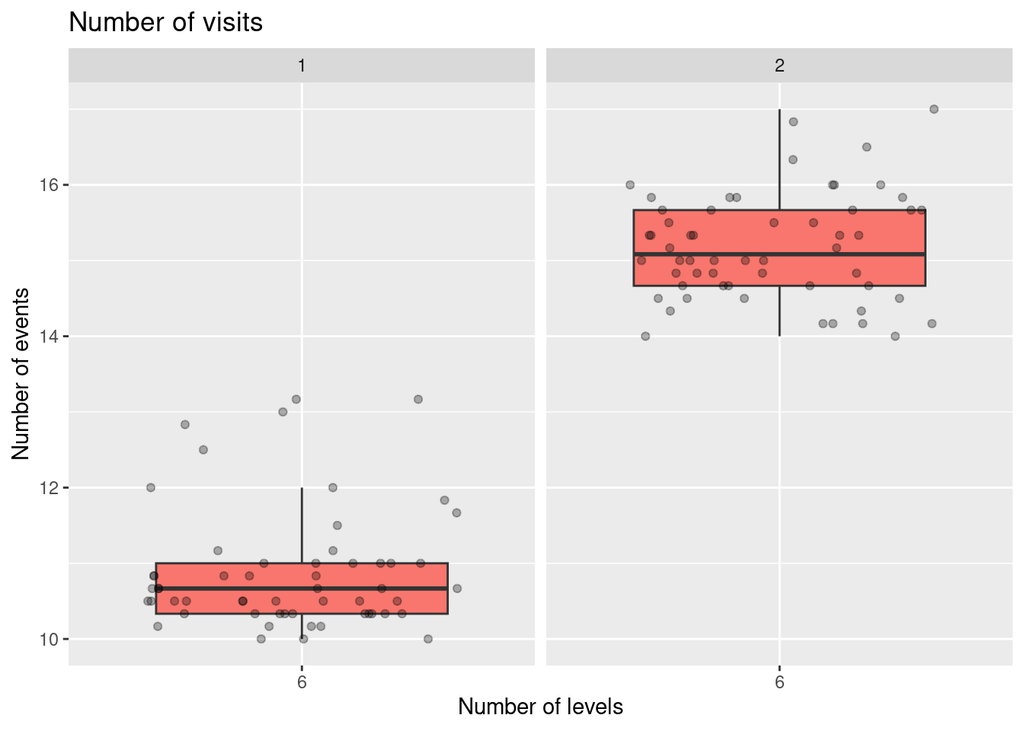

```r
# Create a data frame
condition_info_df <- rbindlist(condition_info)

# Ignore retrieval and last visit
condition_info_df <- condition_info_df[condition_info_df$runType == "e" & condition_info_df$type == 'noveltyScore', ]

# Calculate average
num_event_avg <- ddply(condition_info_df, c('subj', "run", "curr_numLvl"), summarise, num_events = mean(num_events))

# Create factors
num_event_avg$f_run         <- as.factor(num_event_avg$run)
num_event_avg$f_curr_numLvl <- as.factor(num_event_avg$curr_numLvl)

# Visualise
ggplot(num_event_avg, aes(x = f_curr_numLvl, y = num_events, fill = f_curr_numLvl)) +
  facet_grid(~f_run) +
  geom_boxplot(outlier.shape = NA) +
  geom_jitter(height = 0, alpha = 0.3) +
  theme(legend.position = "none") +
  labs(title = "Number of visits", x = "Number of levels", y = "Number of events")
```

### What are the ranges of scores for each level?

Below, we see the range (min & max.) for each participant for each level. The columns are for Run 1 & 2, while the rows are for the different number of different level per analysis.

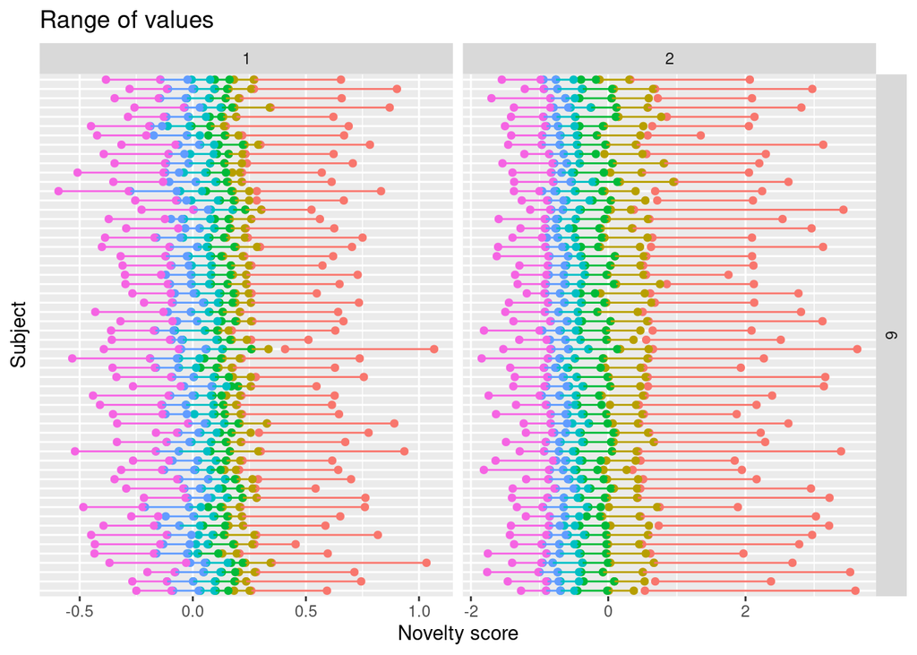

```r
# Create factors
condition_info_df$f_run <- as.factor(condition_info_df$run)
condition_info_df$id <- 1:nrow(condition_info_df)

# Visualise
ggplot(condition_info_df, aes(y = subj, colour = level, group = id)) +
  facet_grid(curr_numLvl~f_run, scales = "free_x") +
  geom_point(aes(x = min_value)) +
  geom_point(aes(x = max_value)) +
  geom_segment(aes(y = subj, yend = subj, x = min_value, xend = max_value)) +
  theme(legend.position = "none",
        axis.text.y = element_blank(),
        axis.ticks.y = element_blank()) +
  labs(title = "Range of values", x = "Novelty score", y = "Subject")
```

Here we see that the levels do cover different ranges of values.

Another way to look at the same question, is to display the range of each level as difference scores (max - min):

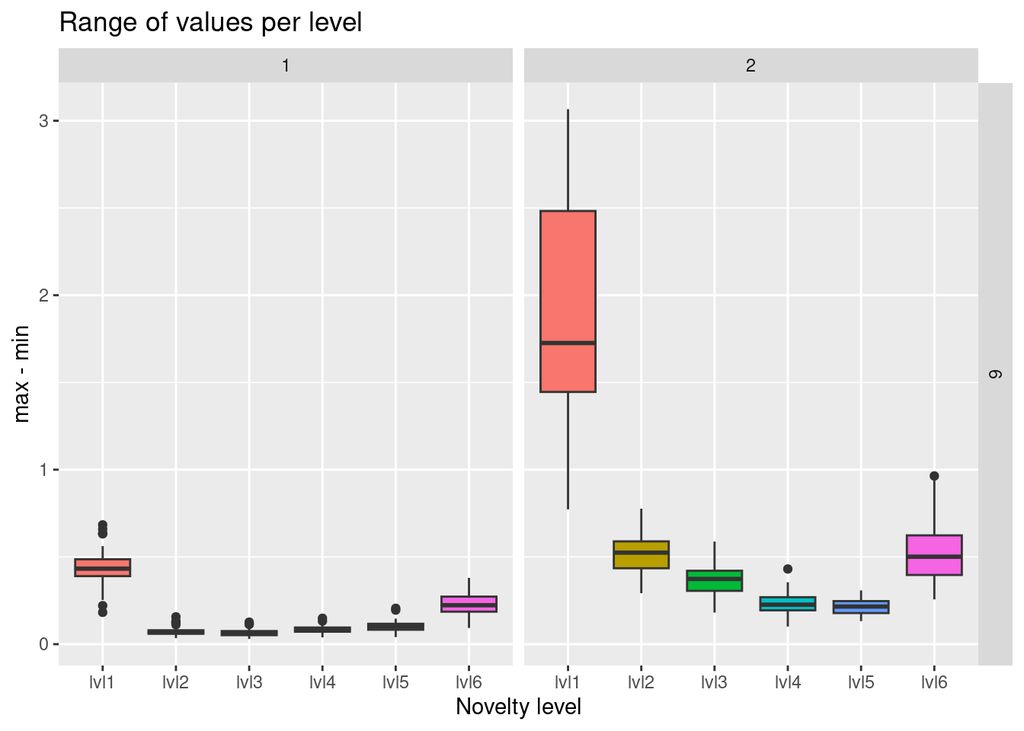

```r
# Calculate level range
condition_info_df$level_range <- condition_info_df$max_value - condition_info_df$min_value

# Visualise
ggplot(condition_info_df, aes(x = level, y = level_range, fill = level)) +
  facet_grid(curr_numLvl~f_run, scales = "free_x") +
  geom_boxplot() +
  theme(legend.position = "none") +
  labs(title = "Range of values per level", x = "Novelty level", y = "max - min")
```

### Distances between levels

Since, we’re not cutting the values in equal pieces based on the range but based on the distribution. The distance between the levels is not equal.

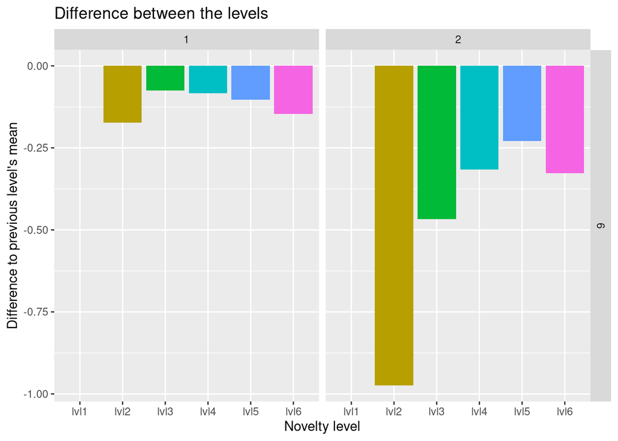

```r
# Calculate the distance between the levels
dist_between_levels <- ddply(condition_info_df, c("curr_numLvl", "f_run", "level"), summarise, mean_value = mean(mean_value))
dist_between_levels <-  ddply(dist_between_levels, c("curr_numLvl","f_run"), mutate, difference = c(NA, diff(mean_value)))

# Visualise
ggplot(dist_between_levels, aes(x = level, y = difference, fill = level)) +
  facet_grid(curr_numLvl~f_run, scales = "free_x") +
  geom_bar(stat = "identity") +
  theme(legend.position = "none") +
  labs(title = "Difference between the levels", x = "Novelty level", y = "Difference to previous level's mean")
```

### The novelty scores

More of sanity check, we plot the average novelty score per level and analysis:

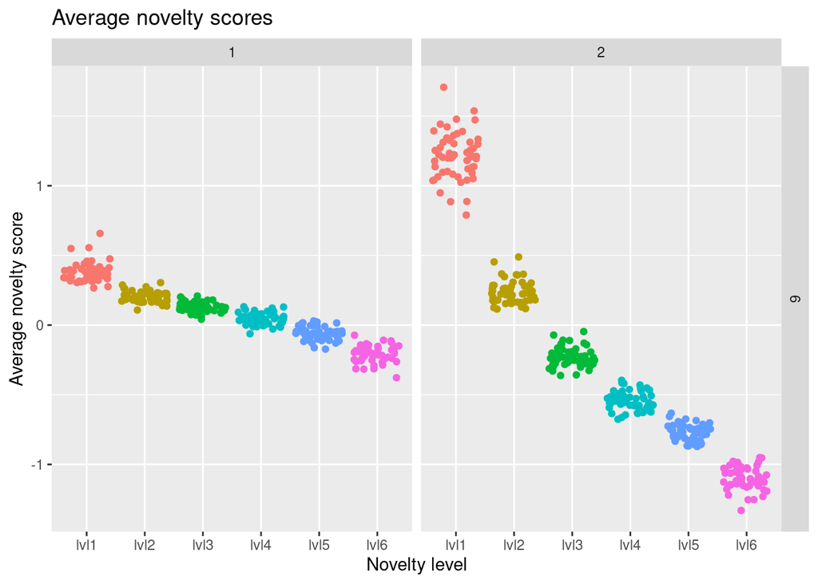

```r
ggplot(condition_info_df, aes(x = level, y = mean_value, colour = level)) +
  facet_grid(curr_numLvl~f_run) +
  geom_jitter(height = 0) +
  theme(legend.position = "none") +
  labs(title = "Average novelty scores", x = "Novelty level", y = "Average novelty score")
```

This does show that each level has lower novelty scores passing this sanity check.

### Loocomotion states as a function of the level

Here, we’re actually only interested in the analysis that we used for the paper, which is the 6-level version of the analysis. The same is to check if locomotion states are different for the different novelty/familiarity levels.

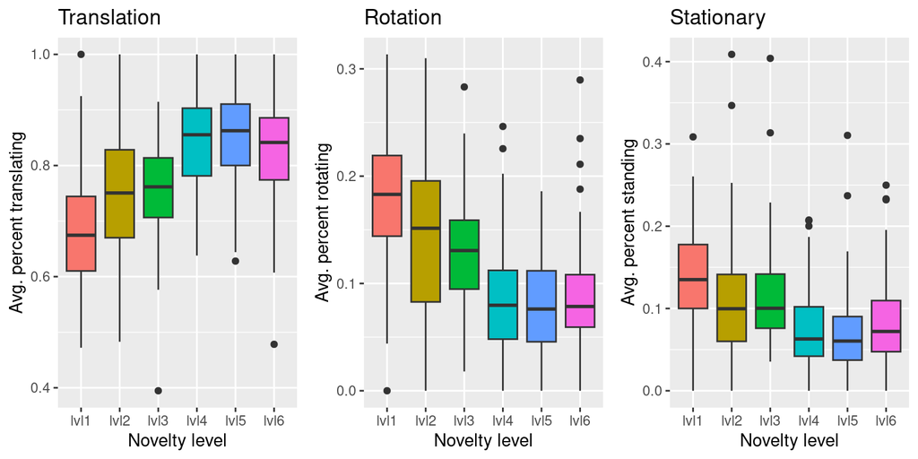

```r
# Subset to the analysis with 6 levels
subData_6levels <- condition_info_df[condition_info_df$curr_numLvl == 6, ]

# Create the plots
p1 <- ggplot(subData_6levels, aes(x = level, y = mean_per_tra, fill = level)) +
  geom_boxplot() +
  theme(legend.position = "none") +
  labs(title = "Translation", x = "Novelty level", y = "Avg. percent translating")

p2 <- ggplot(subData_6levels, aes(x = level, y = mean_per_rot, fill = level)) +
  geom_boxplot() +
  theme(legend.position = "none") +
  labs(title = "Rotation", x = "Novelty level", y = "Avg. percent rotating")

p3 <- ggplot(subData_6levels, aes(x = level, y = mean_per_sta, fill = level)) +
  geom_boxplot() +
  theme(legend.position = "none") +
  labs(title = "Stationary", x = "Novelty level", y = "Avg. percent standing")

plot_grid(p1, p2, p3, ncol = 3)
```

Indeed it seems to be the case that stationary/rotation periods are lower when the sector is more familiar.

### Average distance to the objects and the centre

We’re again only interested in the 6-level variant to see if any of the middle levels are odd in terms of the average distance to the target object of the trial or in terms of the average distance to the closest object.

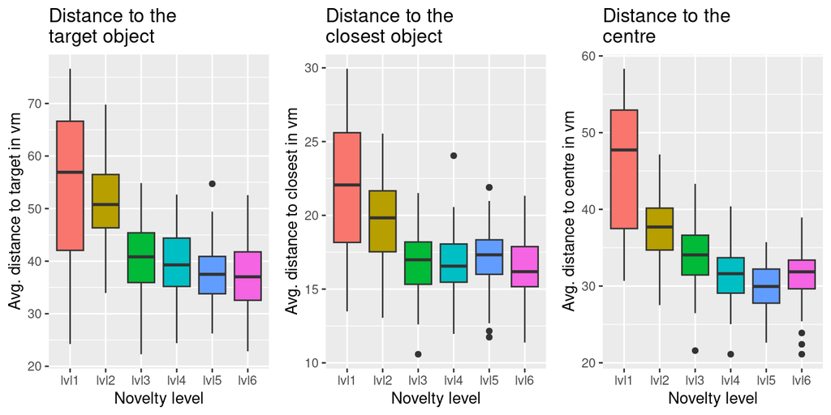

```r
# Create the plots
p1 <- ggplot(subData_6levels, aes(x = level, y = mean_dist2target, fill = level)) +
  geom_boxplot() +
  theme(legend.position = "none") +
  labs(title = "Distance to the\ntarget object",
       x = "Novelty level", y = "Avg. distance to target in vm")

p2 <- ggplot(subData_6levels, aes(x = level, y = mean_dist2closest, fill = level)) +
  geom_boxplot() +
  theme(legend.position = "none") +
  labs(title = "Distance to the\nclosest object",
       x = "Novelty level", y = "Avg. distance to closest in vm")

p3 <- ggplot(subData_6levels, aes(x = level, y = mean_dist2centre, fill = level)) +
  geom_boxplot() +
  theme(legend.position = "none") +
  labs(title = "Distance to the\ncentre",
       x = "Novelty level", y = "Avg. distance to centre in vm")

# Combine plots
plot_grid(p1, p2, p3, nrow = 1)
```

### A couple of further checks

Summary for the plots below:

1. We see tiny variations in terms of the number of events between the levels.
2. Especially in Run 2, the duration of the events does decrease with increasing levels of familiarity.

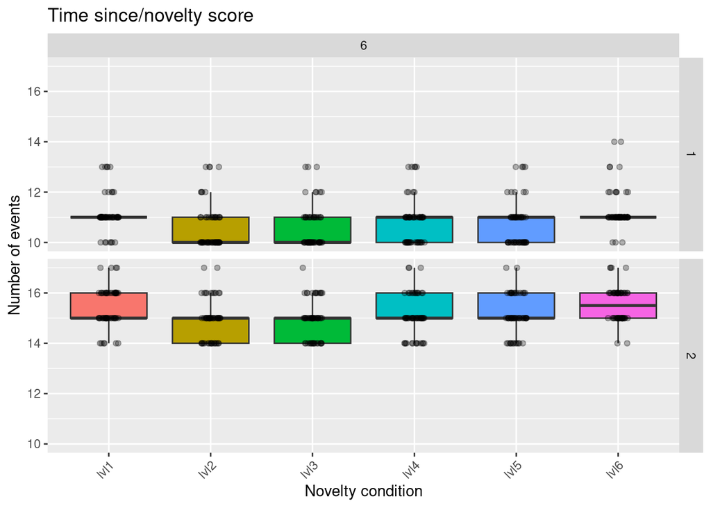

```r
# Plot the number of events per condition
ggplot(condition_info_df, aes(x = level, y = num_events , fill = level)) +
  facet_grid(run~curr_numLvl, scales = "free_x") +
  geom_boxplot(outlier.shape = NA) +
  geom_jitter(height = 0, alpha = 0.3, width = 0.1) +
  theme(legend.position = 'none', axis.text.x = element_text(angle = 45, hjust = 1)) +
  labs(title = "Time since/novelty score", x = "Novelty condition", y = "Number of events")
```

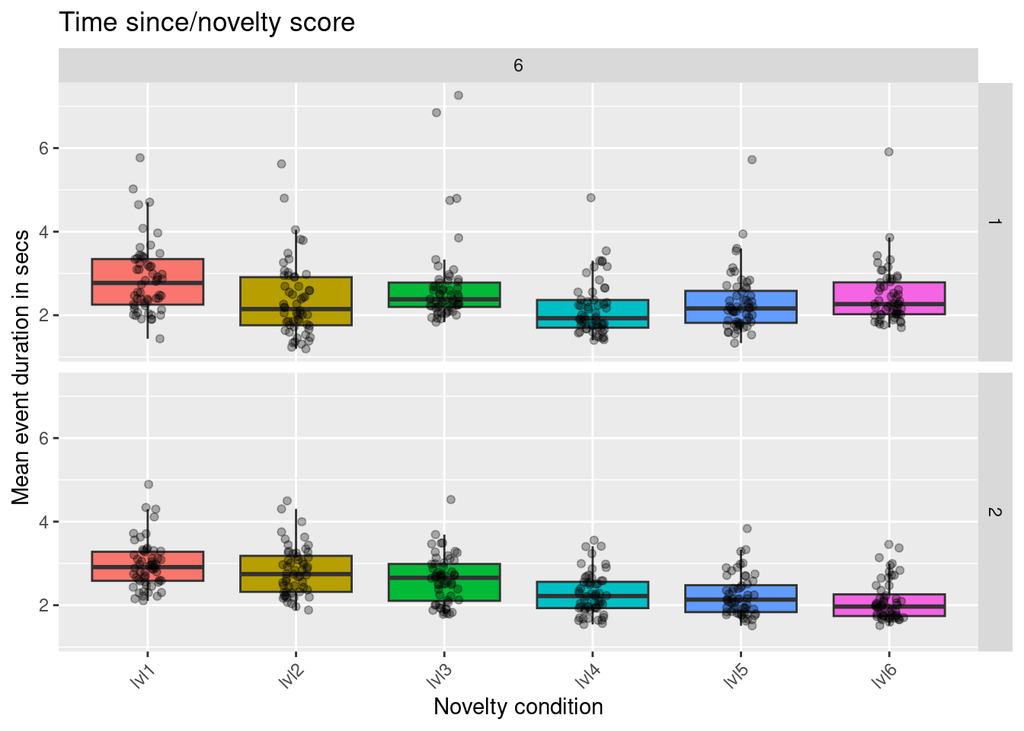

```r
# Calculate unique number of number of events per subject for the level 6
num_events6 <- condition_info_df[condition_info_df$curr_numLvl == 6, ]
num_events6_agg <- ddply(num_events6, c("subj", "f_run"), summarise, length_uniq = length_uniq(num_events))
# Conclusion: The maximum number of unique number of events, which makes sense as not everything is
# dividable into 6 equal numbers

# Plot the duration per condition
ggplot(condition_info_df, aes(x = level, y = mean_duration, fill = level)) +
  facet_grid(run~curr_numLvl, scales = "free_x") +
  geom_boxplot(outlier.shape = NA) +
  geom_jitter(height = 0, alpha = 0.3, width = 0.1) +
  theme(legend.position = 'none', axis.text.x = element_text(angle = 45, hjust = 1)) +
  labs(title = "Time since/novelty score", x = "Novelty condition", y = "Mean event duration in secs")
```

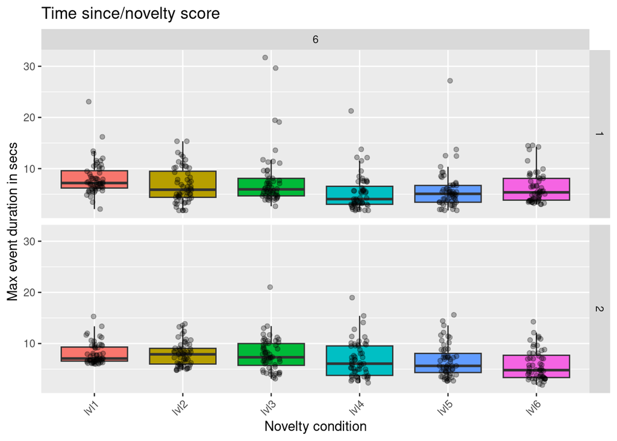

```r
ggplot(condition_info_df, aes(x = level, y = max_duration, fill = level)) +
  facet_grid(run~curr_numLvl, scales = "free_x") +
  geom_boxplot(outlier.shape = NA) +
  geom_jitter(height = 0, alpha = 0.3, width = 0.1) +
  theme(legend.position = 'none', axis.text.x = element_text(angle = 45, hjust = 1)) +
  labs(title = "Time since/novelty score", x = "Novelty condition", y = "Max event duration in secs")
```

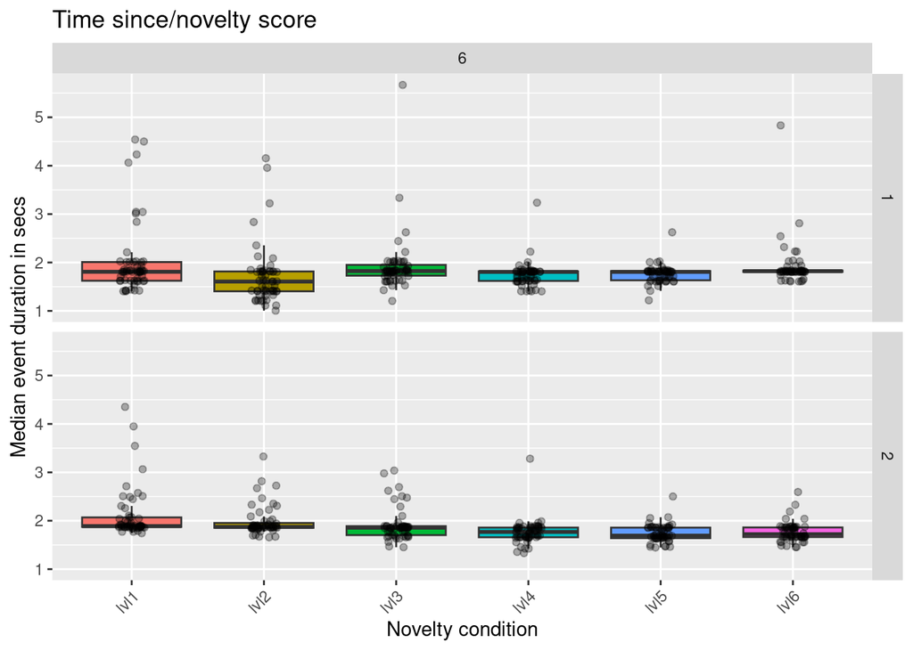

```r
ggplot(condition_info_df, aes(x = level, y = median_duration, fill = level)) +
  facet_grid(run~curr_numLvl, scales = "free_x") +
  geom_boxplot(outlier.shape = NA) +
  geom_jitter(height = 0, alpha = 0.3, width = 0.1) +
  theme(legend.position = 'none', axis.text.x = element_text(angle = 45, hjust = 1)) +
  labs(title = "Time since/novelty score", x = "Novelty condition", y = "Median event duration in secs")
```

# Examining collinearity and variance inflation factor

The codes is adapted from J. Mumford (see https://www.youtube.com/watch?v=H1S72z6o3HY and https://www.youtube.com/watch?v=NJu2lb8uZSg).

```r
# Function to take rhe event epochs and convolve with HRF to make time series
convolve_events <- function(onsets, durations, TR_conv, TR, numScans){
  # Function that the time series for the regressor
  # onsets            : stimulus onset times in seconds
  # durations         : duration (same for stim and resp)
  # TR_conv           : Time resolution used for convolution
  # TR                : TR for the BOLD data
  # numScans          : Number of scans

  # Calculate the number of scans for the specific convolution TR
  numScans_conv <- numScans/TR_conv

  # Comment from J. Mumford
  # Adding this (3/22/2019) because the function seems to have stopped working
  # when I try to use the "times" option of fmri.stimulus
  onsets_scans = onsets/TR_conv

  # Create the regressor
  regressor = fmri.stimulus(scans = numScans_conv,
                               onsets = onsets_scans,
                               durations = durations,
                               #type = "gamma",
                               TR = TR_conv)
  # downsample to TR
  regressor = regressor[seq(from = 1, to = length(regressor), by = 1/TR_conv)]

  # mean center regressor
  regressor = regressor - mean(regressor)

  # Return
  return(regressor)
} # end of function

# Function to calculate vif
calculate_vif <- function(onset, duration, event){
  # Calculate how long the runs was and how many scans it had plus number of event types
  run_duration <- round(max(onset) + max(duration) + 20)
  numScans     <- run_duration/TR
  uni_events   <- unique(event)
  numEvents    <- length(uni_events)

  # Create empty df
  df <- data.frame(matrix(nrow = 0, ncol = 2))

  # Loop through all the events
  for(i in 1:numEvents){
    # Convolve the events with HRF for current event
    regressor <- convolve_events(onset[event == uni_events[i]],
                                 duration[event == uni_events[i]], TR_conv, TR, numScans)

    # Add to df
    df <- rbind(df, data.frame(TR = 1:numScans, event = uni_events[i], AU = regressor))
  }

  # Code for visualising the HRFs
  #ggplot(df, aes(x = TR, y = AU, colour = event)) + geom_line()

  # Convert from long to wide and add data
  df_wide   <- reshape2::dcast(df, TR ~ event, value.var = "AU")
  df_wide$y <- rnorm(nrow(df_wide))

  formula <- paste("y ~", paste(names(df_wide)[c(2:(numEvents+1))], collapse = " + "))

  mod.fake <-  lm(formula, data = df_wide, x = TRUE)
  results  <- vif(mod.fake)

  # Return value
  return(as.numeric(results))
}
```

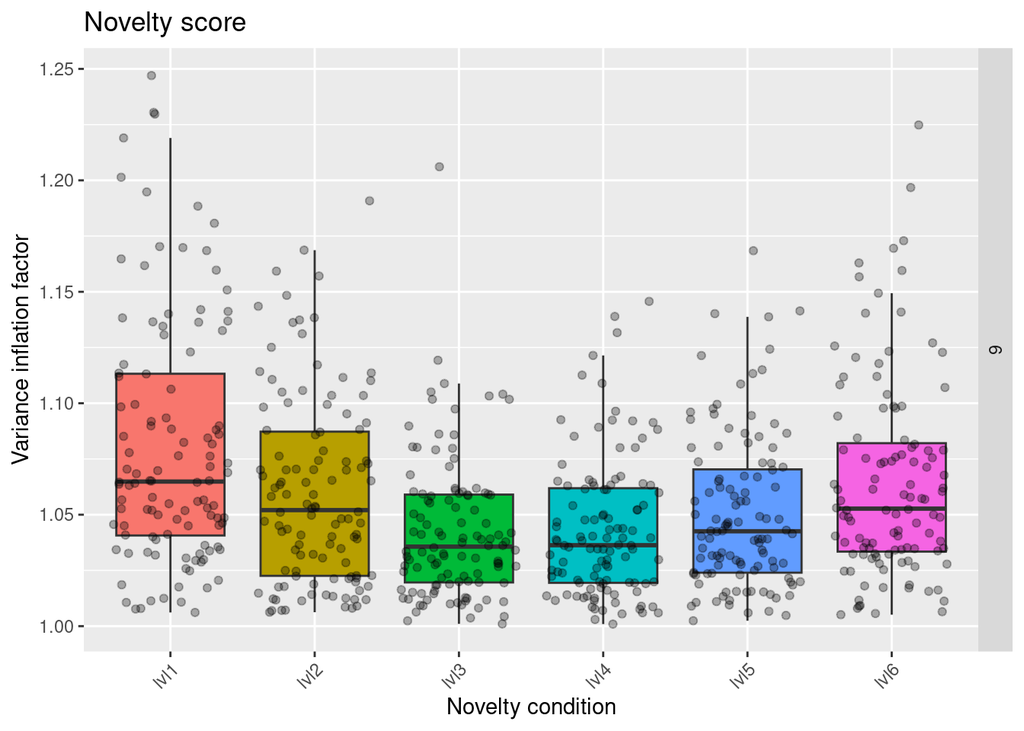

```r
# Parameters
TR      <- 1
TR_conv <- 0.1

# Bind list to df
data <- rbindlist(event_file_list)

# Only encoding
data <- data[data$runType == 'e', ]

# Calculate VIF
VIF_values <- ddply(data, c("subj", "runType", "run", "var", "numLvl"),
                    summarise,VIF = calculate_vif(onset, duration, event), event = unique(event))

VIF_values_sub1 <- VIF_values[VIF_values$var == 'noveltyScore', ]

ggplot(VIF_values_sub1, aes(x = event, y = VIF , fill = event)) +
  facet_grid(numLvl~.) +
  geom_boxplot(outlier.shape = NA) +
  geom_jitter(height = 0, alpha = 0.3) +
  theme(legend.position = 'none', axis.text.x = element_text(angle = 45, hjust = 1)) +
  labs(title = "Novelty score", x = "Novelty condition", y = "Variance inflation factor")
```